# Meta Analysis with R

## 6. 누적메타분석과 민감도분석

### 6-1 누적메타분석

메타분석에서는 전체 분석 결과의 오류 검정에 대한 분석 방법으로 출판 비뚤림 분석과 더불어 ‘누적메타분석’과 ‘민감도분석’이 많이 활용된다. 누적메타분석(cumulative meta-analysis)은 시간의 흐름에 따라 연구 결과나 트렌드가 어떻게 달라지는가를 추적하는 분석 방법이다. 즉, 출판연도별로 정렬하여 시간이 경과함에 따라 효과크기가 어떻게 변화하는지 분석할 수 있다. 또 다른 방법은 연구의 정밀성, 즉 표본이 큰 연구들로부터 차례로 투입하여 효과크기가 어떻게 달라지는지를 분석할 수 있다.

#### 1) 시간적 순서에 따른 누적메타분석

시간적 순서에 따른 누적메타분석을 위해 일차진료기관에서 우울증에 대한 전통적인 치료방법과 여러 전문가를 참여시킨 연합적 치료방법(collaborative care)의 치료효과를 비교한 35개 연구를 살펴보자(Gilbody et al., 2006).

```r
cum <- read.table(text='
study   yi  vi  setting year
"Adler et al, 31(2004)" 0.19    0.01    1   2004
"Akerblad et al, 32(2003)"  0.26    0.009   0   2003
"Araya et al, 33(2003)" 1.13    0.03    0   2003
"Blanchard et al, 34(1995)" 0.43    0.05    0   1995
"Brook et al, 35(2003)" 0   0.03    0   2003
"Bruce et al, 36(2004)" 0.3 0.013   1   2004
"Callahan et al, 37(1994)"  0.05    0.073   1   1994
"Cappocia et al, 38(2004)"  0.17    0.079   1   2004
"Coleman et al, 39(1999)"   -0.14   0.04    1   1999
"Datto et al, 40(2003)" 0.42    0.082   1   2003
"Dietrich et al, 41(2004)"  0.16    0.014   1   2004
"Finley et al, 42(2000)"    -0.3    0.075   1   2000
"Hunkeler et al, 43(2000)"  0.28    0.016   1   2000
"Jarjoura et al, 44(2004)"  0.42    0.044   1   2004
"Katon et al, 45(2001)" 0.11    0.011   1   2001
"Katon et al, 46(2004)" 0.24    0.019   1   2004
"Katon et al, 47(1995)" 0.19    0.024   1   1995
"Katon et al, 47(1996)" 0.49    0.034   1   1996
"Katon et al, 48(1999)" 0.31    0.023   1   1999
"Katzelnick et al, 49(2000)"    0.43    0.011   1   2000
"Mann et al, 50(1998)"  -0.08   0.011   0   1998
"Oslin et al, 51(2003)" 0.61    0.072   1   2003
"Peyeler et al, 16(1999)"   0.21    0.027   0   1999
"Rickles et al, 52(2004)"   0.25    0.1 1   2004
"Rost et al, 53(2001a)" 0.2 0.023   1   2001
"Rost et al, 53(2001b)" 0.29    0.029   1   2001
"Smion et al, 54(2000)" 0.3 0.013   1   2000
"Smion et al, 55(2004a)"    0.18    0.021   1   2004
"Smion et al, 55(2004b)"    0.33    0.021   1   2004
"Swindle et al, 56(2003)"   0.18    0.06    1   2003
"Unutzer et al, 57(2001)"   0.405   0.002   1   2001
"Wells et al, 17(2000 medication)"  0.22    0.015   1   2000
"Wells et al, 17(2000 therapy)" 0.22    0.014   1   2000
"Whooley et al, 58(2000)"   0.16    0.036   1   2000
"Wilkinson et al, 59(1993)" -0.29   0.066   0   1993
', header=T)

cum
```

```
##                               study     yi    vi setting year
## 1             Adler et al, 31(2004)  0.190 0.010       1 2004
## 2          Akerblad et al, 32(2003)  0.260 0.009       0 2003
## 3             Araya et al, 33(2003)  1.130 0.030       0 2003
## 4         Blanchard et al, 34(1995)  0.430 0.050       0 1995
## 5             Brook et al, 35(2003)  0.000 0.030       0 2003
## 6             Bruce et al, 36(2004)  0.300 0.013       1 2004
## 7          Callahan et al, 37(1994)  0.050 0.073       1 1994
## 8          Cappocia et al, 38(2004)  0.170 0.079       1 2004
## 9           Coleman et al, 39(1999) -0.140 0.040       1 1999
## 10            Datto et al, 40(2003)  0.420 0.082       1 2003
## 11         Dietrich et al, 41(2004)  0.160 0.014       1 2004
## 12           Finley et al, 42(2000) -0.300 0.075       1 2000
## 13         Hunkeler et al, 43(2000)  0.280 0.016       1 2000
## 14         Jarjoura et al, 44(2004)  0.420 0.044       1 2004
```

[output cut: 21 more lines]

자료를 연도순으로 정렬하면 다음과 같다.

```r
cum <- cum[order(cum$year),]

head(cum, 10)
```

```
##                        study    yi    vi setting year
## 35 Wilkinson et al, 59(1993) -0.29 0.066       0 1993
## 7   Callahan et al, 37(1994)  0.05 0.073       1 1994
## 4  Blanchard et al, 34(1995)  0.43 0.050       0 1995
## 17     Katon et al, 47(1995)  0.19 0.024       1 1995
## 18     Katon et al, 47(1996)  0.49 0.034       1 1996
## 21      Mann et al, 50(1998) -0.08 0.011       0 1998
## 9    Coleman et al, 39(1999) -0.14 0.040       1 1999
## 19     Katon et al, 48(1999)  0.31 0.023       1 1999
## 23   Peyeler et al, 16(1999)  0.21 0.027       0 1999
## 12    Finley et al, 42(2000) -0.30 0.075       1 2000
```

```
## Loading 'meta' package (version 4.18-1).
## Type 'help(meta)' for a brief overview.
```

```r
fit<- metagen(yi,sqrt(vi),
                 data = cum,
                 studlab = paste(study),
                 comb.fixed = TRUE,
                 comb.random = FALSE,
                 prediction = TRUE,
                 sm = "SMD")
fit
```

```
##                                      SMD            95%-CI %W(fixed)
## Wilkinson et al, 59(1993)        -0.2900 [-0.7935; 0.2135]       0.7
## Callahan et al, 37(1994)          0.0500 [-0.4796; 0.5796]       0.7
## Blanchard et al, 34(1995)         0.4300 [-0.0083; 0.8683]       1.0
## Katon et al, 47(1995)             0.1900 [-0.1136; 0.4936]       2.0
## Katon et al, 47(1996)             0.4900 [ 0.1286; 0.8514]       1.4
## Mann et al, 50(1998)             -0.0800 [-0.2856; 0.1256]       4.4
## Coleman et al, 39(1999)          -0.1400 [-0.5320; 0.2520]       1.2
## Katon et al, 48(1999)             0.3100 [ 0.0128; 0.6072]       2.1
## Peyeler et al, 16(1999)           0.2100 [-0.1121; 0.5321]       1.8
## Finley et al, 42(2000)           -0.3000 [-0.8368; 0.2368]       0.6
## Hunkeler et al, 43(2000)          0.2800 [ 0.0321; 0.5279]       3.0
## Katzelnick et al, 49(2000)        0.4300 [ 0.2244; 0.6356]       4.4
## Smion et al, 54(2000)             0.3000 [ 0.0765; 0.5235]       3.7
## Wells et al, 17(2000 medication)  0.2200 [-0.0200; 0.4600]       3.2
## Wells et al, 17(2000 therapy)     0.2200 [-0.0119; 0.4519]       3.5
## Whooley et al, 58(2000)           0.1600 [-0.2119; 0.5319]       1.4
## Katon et al, 45(2001)             0.1100 [-0.0956; 0.3156]       4.4
## Rost et al, 53(2001a)             0.2000 [-0.0972; 0.4972]       2.1
## Rost et al, 53(2001b)             0.2900 [-0.0438; 0.6238]       1.7
## Unutzer et al, 57(2001)           0.4050 [ 0.3173; 0.4927]      24.3
## Akerblad et al, 32(2003)          0.2600 [ 0.0741; 0.4459]       5.4
## Araya et al, 33(2003)             1.1300 [ 0.7905; 1.4695]       1.6
## Brook et al, 35(2003)             0.0000 [-0.3395; 0.3395]       1.6
## Datto et al, 40(2003)             0.4200 [-0.1412; 0.9812]       0.6
## Oslin et al, 51(2003)             0.6100 [ 0.0841; 1.1359]       0.7
## Swindle et al, 56(2003)           0.1800 [-0.3001; 0.6601]       0.8
## Adler et al, 31(2004)             0.1900 [-0.0060; 0.3860]       4.9
## Bruce et al, 36(2004)             0.3000 [ 0.0765; 0.5235]       3.7
## Cappocia et al, 38(2004)          0.1700 [-0.3809; 0.7209]       0.6
## Dietrich et al, 41(2004)          0.1600 [-0.0719; 0.3919]       3.5
## Jarjoura et al, 44(2004)          0.4200 [ 0.0089; 0.8311]       1.1
## Katon et al, 46(2004)             0.2400 [-0.0302; 0.5102]       2.6
## Rickles et al, 52(2004)           0.2500 [-0.3698; 0.8698]       0.5
## Smion et al, 55(2004a)            0.1800 [-0.1040; 0.4640]       2.3
## Smion et al, 55(2004b)            0.3300 [ 0.0460; 0.6140]       2.3
##
## Number of studies combined: k = 35
##
##                        SMD            95%-CI     z  p-value
## Fixed effect model  0.2757 [ 0.2325; 0.3190] 12.51 < 0.0001
## Prediction interval        [-0.0583; 0.5532]
##
## Quantifying heterogeneity:
##  tau^2 = 0.0213 [0.0071; 0.0618]; tau = 0.1458 [0.0843; 0.2486]
##  I^2 = 54.1% [32.7%; 68.7%]; H = 1.48 [1.22; 1.79]
##
## Test of heterogeneity:
##      Q d.f.  p-value
##  74.10   34 < 0.0001
##
## Details on meta-analytical method:
## - Inverse variance method
## - DerSimonian-Laird estimator for tau^2
## - Jackson method for confidence interval of tau^2 and tau
```

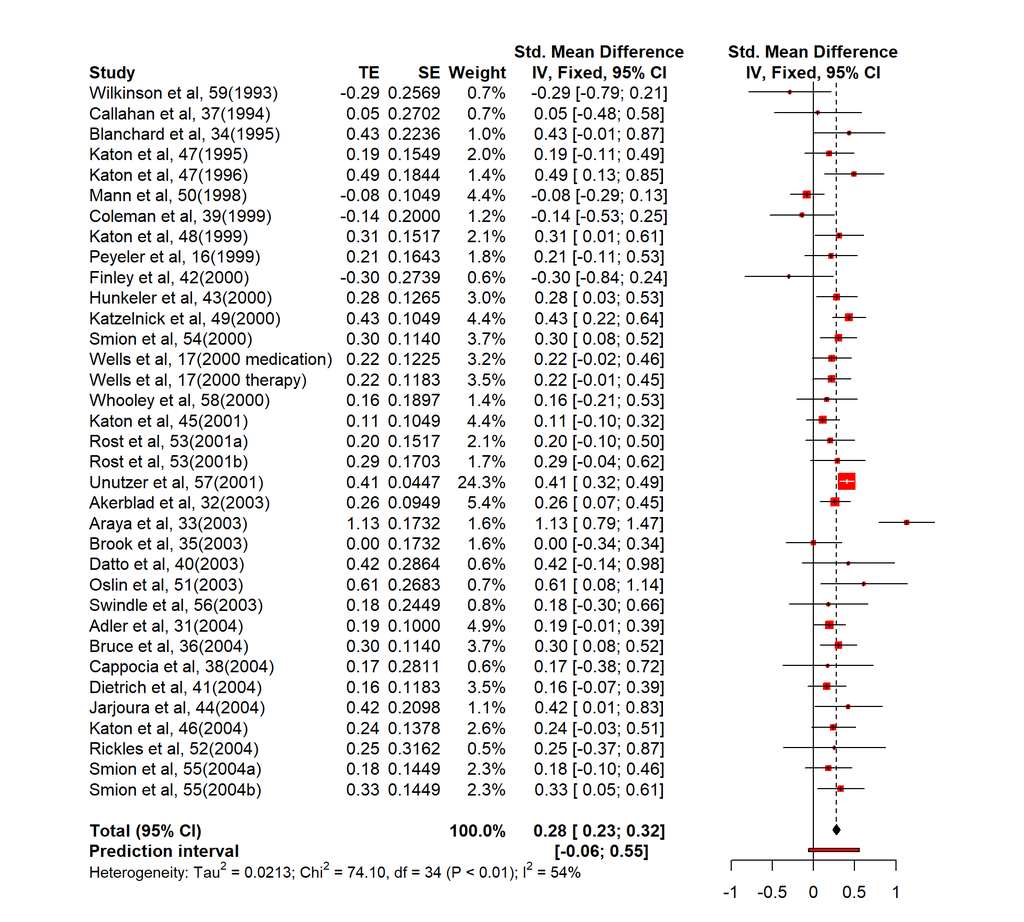

```r
forest(fit, layout="RevMan5")
```

**meta** packages에서 누적메타분석(cumulative meta-analysis)는 *metacum* 함수를 이용한다.

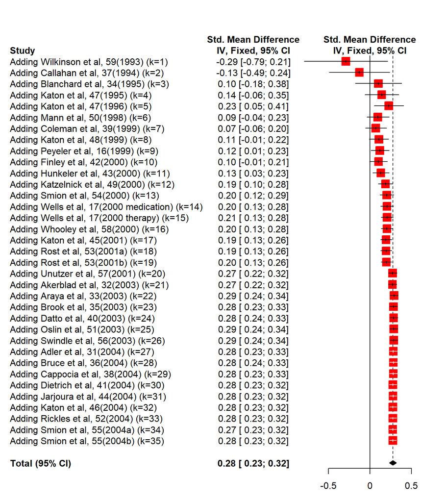

```r
forest(metacum(fit), layout="RevMan5")
```

누적분석 결과를 살펴보면, 1990년대 중반 이후 특히 2000년대에 들어서면서 연합적 치료방법의 효과가 전통적인 치료방법에 비해 긍정적이면서 안정적인 결과(0.20~0.28)를 보여주고 있음을 알 수 있다.

#### 2) 표본크기에 따른 누적메타분석

누적메타분석은 시간의 흐름에 따라 결과가 어떻게 축적되어 나타나는지를 검증하는 방법으로 고안되었지만 표본크기가 큰 연구부터 투입하여 효과크기가 어떻게 변화하는지를 분석할 수 있다. 즉, 표본크기가 큰 연구들부터 차례로 투입함으로써 효과크기가 어느 정도 안정화(stabilized)되면 표본크기가 작은 연구들을 더 투입해도 효과크기에 큰 변화가 나타나지 않는지를 확인한다. 만약 그렇게 되면 작은 연구들이 전체효과크기에 영향을 미친다고 보기 어렵다.

앞서 사용한 간접흡연이 배우자의 폐암 발생에 미치는 영향을 분석한 자료로 살펴보자.

**meta** packages에서 누적메타분석(cumulative meta-analysis)는 *metacum* 함수를 이용한다.

```r
publi <- read.table(text='
study yi lower upper vi
study_1 -0.288  -0.84084    0.265475    0.079649
study_2 0.728   -0.20691    1.662006    0.227305
study_3 0.756   0.171673    1.340567    0.088916
study_4 -0.223  -1.08347    0.637175    0.192668
study_5 -0.236  -1.3769 0.905448    0.338993
study_6 0.698   0.084369    0.311897    0.09806
study_7 0.207   -0.21131    0.625334    0.045553
study_8 0.182   -0.76119    1.125838    0.231731
study_9 0.419   -0.1344 0.971824    0.079637
study_10    0.03    -0.88426    0.943388    0.217377
study_11    0.438   -0.10545    0.981966    0.076952
study_12    0.03    -0.49453    0.553638    0.071497
study_13    0.85    -0.20996    1.910264    0.292543
study_14    0.501   0.147782    0.853768    0.032435
study_15    0.174   -0.19933    0.547231    0.036271
study_16    0.419   -0.9461 1.782026    0.483819
study_17    0.77    0.080455    1.459759    0.123808
study_18    0.077   -0.44558    0.599512    0.071079
study_19    0.936   -0.30067    2.17861 0.398166
study_20    0.482   -0.10432    1.069173    0.089616
study_21    0.058   -0.30163    0.418171    0.033717
study_22    -0.236  -0.48464    0.013193    0.016128
study_23    -0.301  -1.13317    0.530963    0.180221
study_24    0.82    -0.28397    1.92353 0.317124
study_25    -0.03   -0.25   0.189074    0.012546
study_26    0.47    -0.19086    1.13087 0.113687
study_27    0.174   -0.41186    0.759763    0.089331
study_28    0.507   -0.31538    1.32902 0.175972
study_29    0.231   0.034836    0.42739 0.010028
study_30    0.095   -0.48017    0.670789    0.086208
study_31    0.507   0.115443    0.898192    0.039872
study_32    0.148   -0.22551    0.522347    0.06397
study_33    0.104   -0.40075    0.609472    0.066414
study_34    0.166   -0.10305    0.434078    0.018775
study_35    0.372   0.015283    0.727838    0.033042
study_36    0.703   -0.73741    2.143606    0.540157
study_37    0.182   -0.11094    0.475588    0.022388
', header=T)

publi
```

```
##       study     yi     lower    upper       vi
## 1   study_1 -0.288 -0.840840 0.265475 0.079649
## 2   study_2  0.728 -0.206910 1.662006 0.227305
## 3   study_3  0.756  0.171673 1.340567 0.088916
## 4   study_4 -0.223 -1.083470 0.637175 0.192668
## 5   study_5 -0.236 -1.376900 0.905448 0.338993
## 6   study_6  0.698  0.084369 0.311897 0.098060
## 7   study_7  0.207 -0.211310 0.625334 0.045553
## 8   study_8  0.182 -0.761190 1.125838 0.231731
## 9   study_9  0.419 -0.134400 0.971824 0.079637
## 10 study_10  0.030 -0.884260 0.943388 0.217377
## 11 study_11  0.438 -0.105450 0.981966 0.076952
## 12 study_12  0.030 -0.494530 0.553638 0.071497
## 13 study_13  0.850 -0.209960 1.910264 0.292543
## 14 study_14  0.501  0.147782 0.853768 0.032435
```

[output cut: 23 more lines]

```r
publi2 <- publi[order(publi$vi),]
fit_pub2<- metagen(yi,sqrt(vi),
                 data = publi2,
                 studlab = paste(study),
                 comb.fixed = TRUE,
                 comb.random = FALSE,
                 prediction = TRUE,
                 sm = "RR")
fit_pub2
```

```
##              RR           95%-CI %W(fixed)
## study_29 1.2599 [1.0353; 1.5331]      13.9
## study_25 0.9704 [0.7792; 1.2087]      11.1
## study_22 0.7898 [0.6158; 1.0130]       8.6
## study_34 1.1806 [0.9025; 1.5443]       7.4
## study_37 1.1996 [0.8947; 1.6084]       6.2
## study_14 1.6504 [1.1595; 2.3490]       4.3
## study_35 1.4506 [1.0159; 2.0715]       4.2
## study_21 1.0597 [0.7394; 1.5188]       4.1
## study_15 1.1901 [0.8193; 1.7285]       3.8
## study_31 1.6603 [1.1226; 2.4556]       3.5
## study_7  1.2300 [0.8095; 1.8688]       3.1
## study_32 1.1595 [0.7063; 1.9035]       2.2
## study_33 1.1096 [0.6696; 1.8388]       2.1
## study_18 1.0800 [0.6405; 1.8213]       2.0
## study_12 1.0305 [0.6101; 1.7403]       1.9
## study_11 1.5496 [0.8997; 2.6690]       1.8
## study_9  1.5204 [0.8745; 2.6435]       1.7
## study_1  0.7498 [0.4312; 1.3036]       1.7
## study_30 1.0997 [0.6185; 1.9552]       1.6
## study_3  2.1297 [1.1872; 3.8207]       1.6
## study_27 1.1901 [0.6625; 2.1378]       1.6
## study_20 1.6193 [0.9006; 2.9117]       1.6
## study_6  2.0097 [1.0879; 3.7127]       1.4
## study_26 1.6000 [0.8263; 3.0983]       1.2
## study_17 2.1598 [1.0837; 4.3044]       1.1
## study_28 1.6603 [0.7297; 3.7780]       0.8
## study_23 0.7401 [0.3220; 1.7007]       0.8
## study_4  0.8001 [0.3385; 1.8914]       0.7
## study_10 1.0305 [0.4132; 2.5697]       0.6
## study_2  2.0709 [0.8135; 5.2722]       0.6
## study_8  1.1996 [0.4670; 3.0817]       0.6
## study_13 2.3396 [0.8105; 6.7537]       0.5
## study_24 2.2705 [0.7530; 6.8464]       0.4
## study_5  0.7898 [0.2523; 2.4723]       0.4
## study_19 2.5498 [0.7403; 8.7824]       0.3
## study_16 1.5204 [0.3890; 5.9435]       0.3
## study_36 2.0198 [0.4783; 8.5291]       0.3
##
## Number of studies combined: k = 37
##
##                         RR           95%-CI    z  p-value
## Fixed effect model  1.2048 [1.1199; 1.2962] 5.00 < 0.0001
## Prediction interval        [0.9350; 1.6424]
##
## Quantifying heterogeneity:
##  tau^2 = 0.0170 [0.0000; 0.0680]; tau = 0.1305 [0.0000; 0.2607]
##  I^2 = 24.2% [0.0%; 49.8%]; H = 1.15 [1.00; 1.41]
##
## Test of heterogeneity:
##      Q d.f. p-value
##  47.49   36  0.0952
##
## Details on meta-analytical method:
## - Inverse variance method
## - DerSimonian-Laird estimator for tau^2
## - Jackson method for confidence interval of tau^2 and tau
```

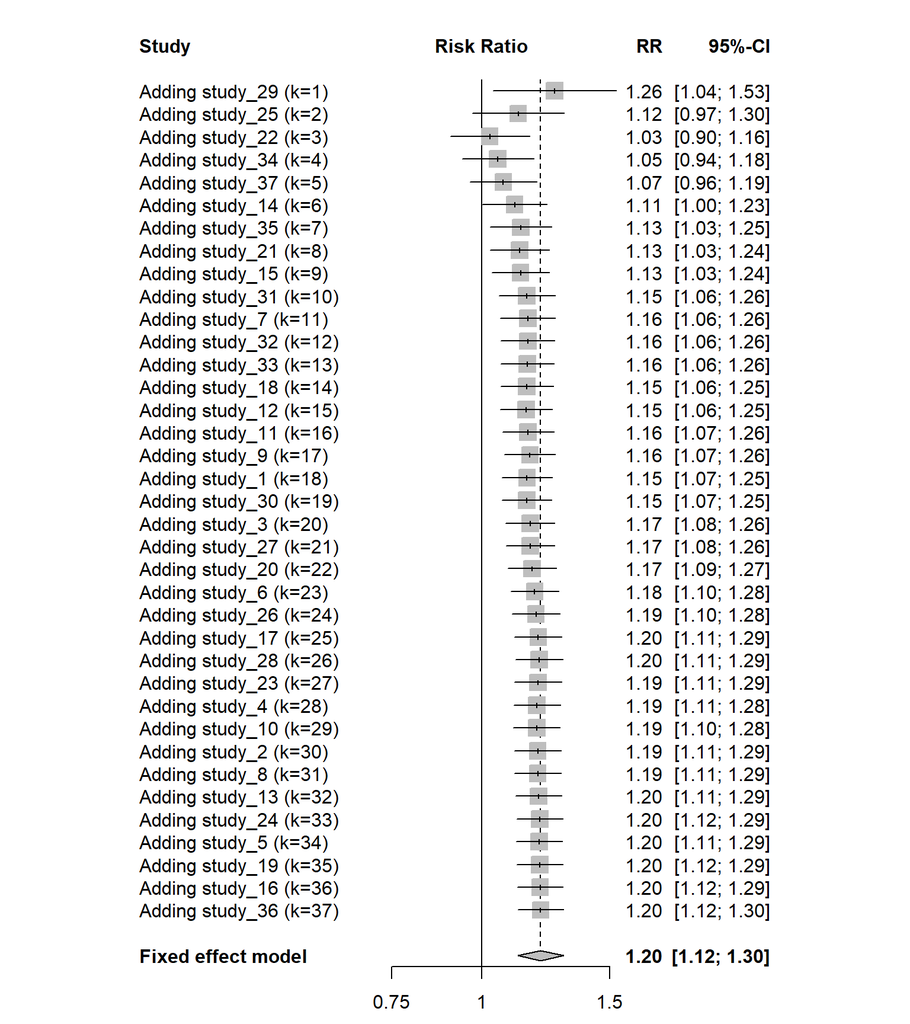

```r
forest(metacum(fit_pub2, sortvar=publi2$vi) )
```

연구 크기순으로 22개(study 20까지) 연구를 투입했을 때(이때 누적가중치는 $90\%$에 달하는데) 전체효과크기는 1.17로 나타났다. 그리고 나머지 15개의 상대적으로 작은 연구들을 투입하여도 전체효과크기는 1.20으로 조금 증가해 전체 결과에 큰 영향을 미치지는 못하는 것으로 나타났따. 따라서 효과의 크기가 큰 것으로 나타난 작은 표본의 연구들이 전체 결과에 영향을 주는, 즉 비뚤림을 일으키는 원인이라고 말할 수 없다고 하겠다.

요약하면 누적메타분석은 각 연구들이 더해지면서 평균효과크기와 신뢰구간이 어떻게 달라지는 지를 보여준다. 그리고 누적메타분석은 민감도분석의 한 부분으로도 활용될 수 있어 새로운 연구들이 추가되면서 연구 결과(결론)가 어떻게 달라지는지 또는 변함이 없는지를 보여준다.

### 6-2 민감도분석

민감도분석(sensitivity analysis)은 분석의 기준이나 내용에 따라 그 결과가 어떻게(민감하게) 변화하는지를 검토하는 분석 방법으로, 그 기준은 다음과 같다.

| 기준 | 내용 |
| --- | --- |
| 연구 포함 기준 | 기준에 따라 어떤 특정한 연구나 몇몇 연구가 누락되게 되면 전체적인 결론이 크게 다른게 나타나는가를 검증한다. |
| 통계적 방법 | 효과크기의 종류(risk ratio 또는 odds ratio), 효과크기의 산출 모형(고정효과모형 또는 랜덤효과모형) |
| 누락된 데이터를 다루는 방법 | 누락된 연구를 포함시켰을 때 결과가 어느 정도 달라지는가를 검층한다(예: trim-and fill) |

민감도분석은 서로 다른 조건(가정)하에서 도출된 분석 결과가 일관성을 보이는지 검증하는 방법이라고 할 수 있다. 즉 체계적 리뷰 과정에서 이루어진 여러 가지 결정의 영향력을 검증하기 위해 그리고 누락된 데이터의 영향을 탐색하기 위해 사용할 수 있다.

```
## Extensive documentation for the dmetar package can be found at:
##  www.bookdown.org/MathiasHarrer/Doing_Meta_Analysis_in_R/
```

```r
madata <- read.table(text='
Author  TE  seTE
"Call et al."   0.7091  0.2608
"Cavanagh et al."   0.3549  0.1964
"DanitzOrsillo" 1.7912  0.3456
"de Vibe et al."    0.1825  0.1178
"Frazier et al."    0.4219  0.1448
"Frogeli et al."    0.6300  0.1960
"Gallego et al."    0.7249  0.2247
"Hazlett-Stevens & Oren"    0.5287  0.2105
"Hintz et al."  0.2840  0.1680
"Kang et al."   1.2751  0.3372
"Kuhlmann et al."   0.1036  0.1947
"Lever Taylor et al."   0.3884  0.2308
"Phang et al."  0.5407  0.2443
"Rasanen et al."    0.4262  0.2579
"Ratanasiripong"    0.5154  0.3513
"Shapiro et al."    1.4797  0.3153
"SongLindquist" 0.6126  0.2267
"Warnecke et al."   0.6000  0.2490
', header=T)

madata
```

```
##                    Author     TE   seTE
## 1             Call et al. 0.7091 0.2608
## 2         Cavanagh et al. 0.3549 0.1964
## 3           DanitzOrsillo 1.7912 0.3456
## 4          de Vibe et al. 0.1825 0.1178
## 5          Frazier et al. 0.4219 0.1448
## 6          Frogeli et al. 0.6300 0.1960
## 7          Gallego et al. 0.7249 0.2247
## 8  Hazlett-Stevens & Oren 0.5287 0.2105
## 9            Hintz et al. 0.2840 0.1680
## 10            Kang et al. 1.2751 0.3372
## 11        Kuhlmann et al. 0.1036 0.1947
## 12    Lever Taylor et al. 0.3884 0.2308
## 13           Phang et al. 0.5407 0.2443
## 14         Rasanen et al. 0.4262 0.2579
## 15         Ratanasiripong 0.5154 0.3513
## 16         Shapiro et al. 1.4797 0.3153
## 17          SongLindquist 0.6126 0.2267
## 18        Warnecke et al. 0.6000 0.2490
```

```r
  m.hksj <- metagen(TE,
                  seTE,
                  data = madata,
                  studlab = paste(Author),
                  comb.fixed = FALSE,
                  comb.random = TRUE,
                  method.tau = "SJ",
                  hakn = TRUE,
                  prediction = TRUE,
                  sm = "SMD")
m.hksj
```

```
##                           SMD            95%-CI %W(random)
## Call et al.            0.7091 [ 0.1979; 1.2203]        5.2
## Cavanagh et al.        0.3549 [-0.0300; 0.7398]        6.1
## DanitzOrsillo          1.7912 [ 1.1138; 2.4686]        4.2
## de Vibe et al.         0.1825 [-0.0484; 0.4134]        7.1
## Frazier et al.         0.4219 [ 0.1381; 0.7057]        6.8
## Frogeli et al.         0.6300 [ 0.2458; 1.0142]        6.1
## Gallego et al.         0.7249 [ 0.2845; 1.1653]        5.7
## Hazlett-Stevens & Oren 0.5287 [ 0.1161; 0.9413]        5.9
## Hintz et al.           0.2840 [-0.0453; 0.6133]        6.5
## Kang et al.            1.2751 [ 0.6142; 1.9360]        4.3
## Kuhlmann et al.        0.1036 [-0.2780; 0.4852]        6.1
## Lever Taylor et al.    0.3884 [-0.0640; 0.8408]        5.6
## Phang et al.           0.5407 [ 0.0619; 1.0195]        5.4
## Rasanen et al.         0.4262 [-0.0793; 0.9317]        5.3
## Ratanasiripong         0.5154 [-0.1731; 1.2039]        4.1
## Shapiro et al.         1.4797 [ 0.8617; 2.0977]        4.5
## SongLindquist          0.6126 [ 0.1683; 1.0569]        5.7
## Warnecke et al.        0.6000 [ 0.1120; 1.0880]        5.4
##
## Number of studies combined: k = 18
##
##                         SMD            95%-CI    t  p-value
## Random effects model 0.5935 [ 0.3892; 0.7979] 6.13 < 0.0001
## Prediction interval         [-0.2083; 1.3954]
##
## Quantifying heterogeneity:
##  tau^2 = 0.1337 [0.0295; 0.3533]; tau = 0.3656 [0.1717; 0.5944]
##  I^2 = 62.6% [37.9%; 77.5%]; H = 1.64 [1.27; 2.11]
##
## Test of heterogeneity:
##      Q d.f. p-value
##  45.50   17  0.0002
##
## Details on meta-analytical method:
## - Inverse variance method
## - Sidik-Jonkman estimator for tau^2
## - Q-profile method for confidence interval of tau^2 and tau
## - Hartung-Knapp adjustment for random effects model
```

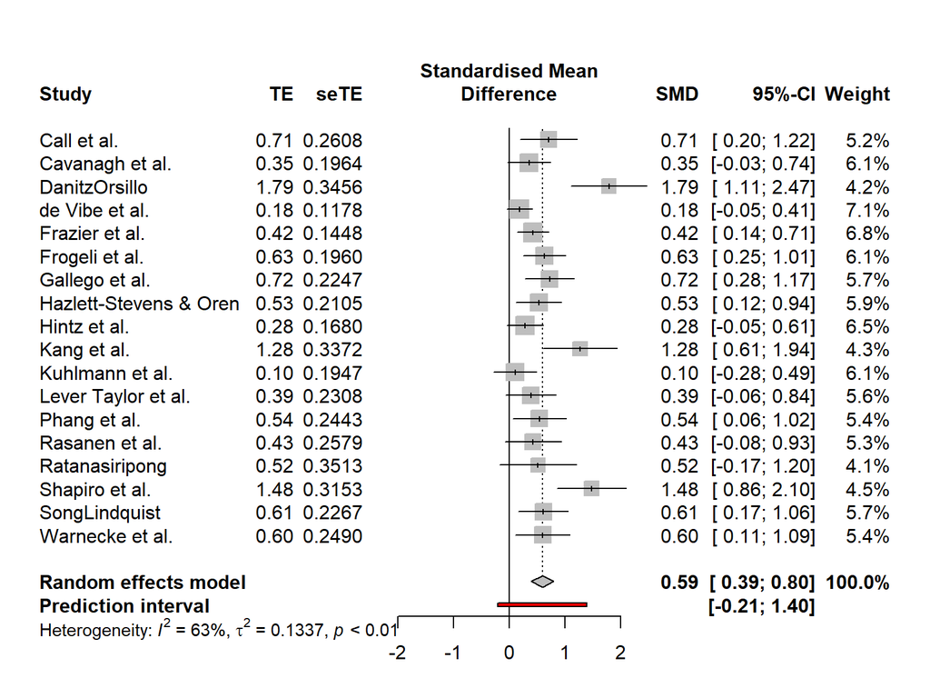

```r
forest(m.hksj )
```

```r
inf.analysis <- InfluenceAnalysis(x = m.hksj,
                                  random = TRUE)
```

```
## [===========================================================================] DONE
```

```r
summary(inf.analysis)
```

```
## Leave-One-Out Analysis (Sorted by I2)
##  -----------------------------------
##                                 Effect  LLCI  ULCI    I2
## Omitting DanitzOrsillo           0.527 0.362 0.691 0.481
## Omitting Shapiro et al.          0.544 0.358 0.731 0.545
## Omitting de Vibe et al.          0.624 0.414 0.835 0.576
## Omitting Kang et al.             0.560 0.360 0.761 0.598
## Omitting Kuhlmann et al.         0.624 0.417 0.831 0.614
## Omitting Hintz et al.            0.616 0.401 0.830 0.636
## Omitting Gallego et al.          0.588 0.370 0.806 0.638
## Omitting Call et al.             0.590 0.372 0.807 0.642
## Omitting Frogeli et al.          0.594 0.375 0.813 0.643
## Omitting Cavanagh et al.         0.611 0.394 0.827 0.645
## Omitting SongLindquist           0.595 0.376 0.814 0.646
## Omitting Warnecke et al.         0.596 0.377 0.814 0.646
## Omitting Frazier et al.          0.608 0.390 0.826 0.647
## Omitting Lever Taylor et al.     0.608 0.391 0.824 0.647
## Omitting Hazlett-Stevens & Oren  0.600 0.381 0.819 0.648
## Omitting Phang et al.            0.599 0.381 0.818 0.648
## Omitting Rasanen et al.          0.605 0.388 0.822 0.648
## Omitting Ratanasiripong          0.599 0.382 0.816 0.648
##
##
## Influence Diagnostics
##  -------------------
##                                 rstudent dffits cook.d cov.r QE.del   hat
## Omitting Call et al.               0.253  0.038  0.001 1.114 44.700 0.052
## Omitting Cavanagh et al.          -0.586 -0.163  0.027 1.101 45.060 0.061
## Omitting DanitzOrsillo             2.828  0.746  0.423 0.694 30.815 0.042
## Omitting de Vibe et al.           -1.121 -0.304  0.091 1.058 37.740 0.071
## Omitting Frazier et al.           -0.445 -0.137  0.020 1.120 45.311 0.068
## Omitting Frogeli et al.            0.082 -0.002  0.000 1.127 44.875 0.061
## Omitting Gallego et al.            0.302  0.053  0.003 1.118 44.254 0.057
## Omitting Hazlett-Stevens & Oren   -0.160 -0.062  0.004 1.122 45.441 0.059
## Omitting Hintz et al.             -0.790 -0.215  0.047 1.087 43.999 0.065
## Omitting Kang et al.               1.445  0.332  0.104 0.970 39.823 0.043
## Omitting Kuhlmann et al.          -1.242 -0.301  0.087 1.025 41.492 0.061
## Omitting Lever Taylor et al.      -0.483 -0.134  0.019 1.103 45.329 0.056
## Omitting Phang et al.             -0.126 -0.053  0.003 1.118 45.433 0.054
## Omitting Rasanen et al.           -0.381 -0.109  0.012 1.105 45.450 0.053
```

[output cut: 31 more lines]

```
## Omitting Kang et al.                 5.553               0.121
## Omitting Kuhlmann et al.             3.748               0.256
## Omitting Hintz et al.                1.368               0.129
## Omitting Gallego et al.              1.183               0.060
## Omitting Call et al.                 0.768               0.028
## Omitting Frogeli et al.              0.582               0.039
## Omitting Cavanagh et al.             0.409               0.027
## Omitting SongLindquist               0.339               0.017
## Omitting Warnecke et al.             0.230               0.009
## Omitting Frazier et al.              0.164               0.021
## Omitting Lever Taylor et al.         0.159               0.008
## Omitting Phang et al.                0.061               0.003
## Omitting Hazlett-Stevens & Oren      0.052               0.003
## Omitting Rasanen et al.              0.044               0.002
## Omitting Ratanasiripong              0.010               0.000
```

Leave-one-out Analysis

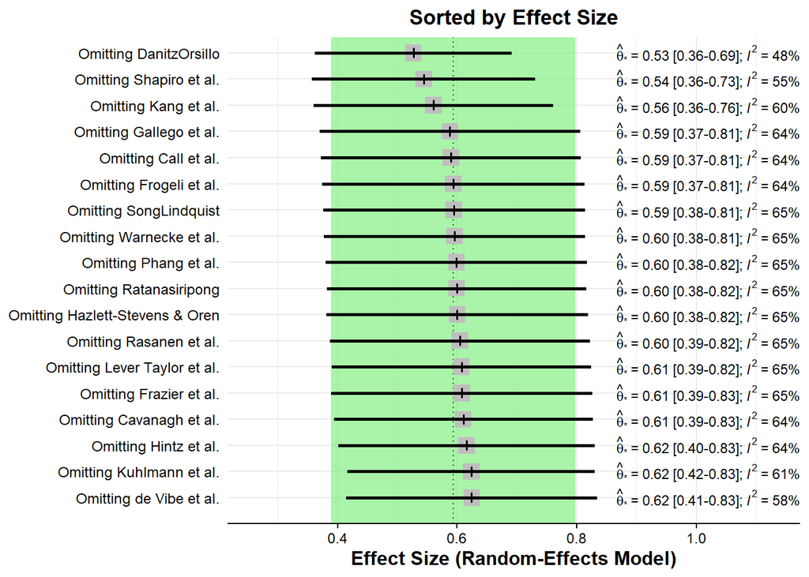

```r
plot(inf.analysis, "es")
```

즉 어떤 특정한 연구를 제외하거나 또는 포함시켰을 때 전체 평균효과크기가 어떻게 달라지며, 전체 연구 결과에 얼마나 변화가 있는지를 검증하는 것이 바로 민감도분석의 목적이다.